# Final Project

April Shipley-Mellon

21 May, 2020

# Packages and Data

```r
setwd("~/Desktop/MTH250")
library(tidyverse)
library(scales)
```

```r
epi<-read.csv("EPI.csv")
snapchat<- read.csv("SnapchatData.csv",skip=1)
```

# Environmental Performance Index Scores

# Background

The Environmental Performance Index (EPI) Report is a study conducted by Yale and Columbia University that ranks 180 countries on 24 different environmental performance indicators. The scoring system is rather complicated, but each of these 24 indictors are split between 2 categories, ecosystem vitality and environmental health, as well as other small groups with specific focuses, such as water resources or air quality. Every country is given a score in each of these categories, as well as a ranking. These scores will then be compiled to give an overall score and ranking for each country. The EPI Report splits the 180 countries into 8 regions. This graph focuses on the regional differences in EPI scores.

More information about the EPI report can be found at: https://epi.envirocenter.yale.edu/

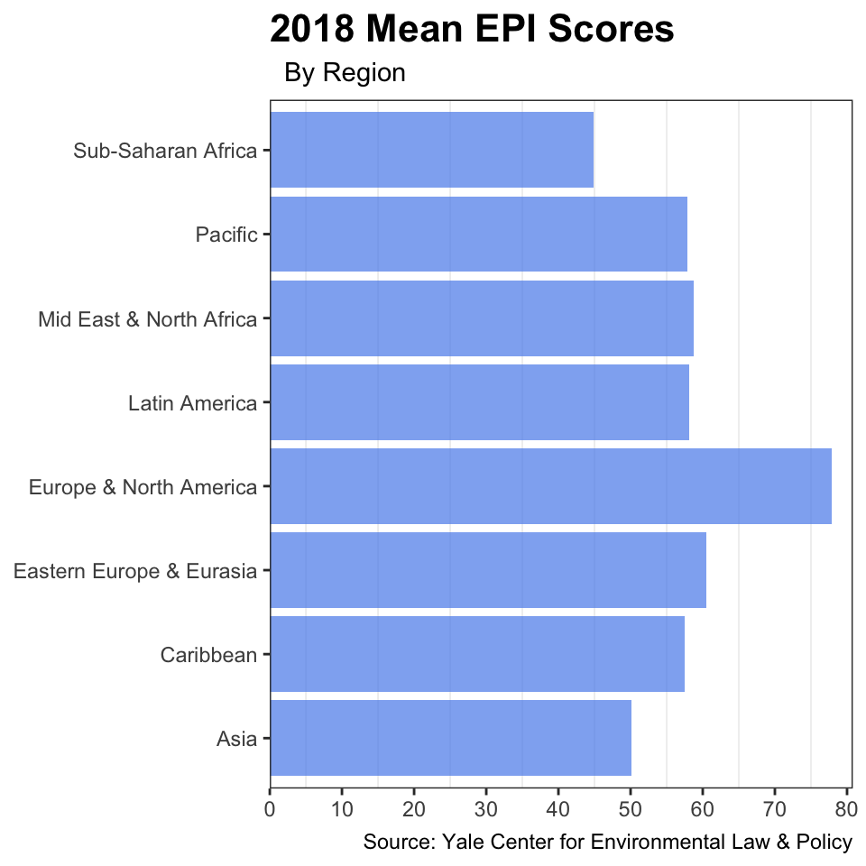

```r
  sum <- epi %>%
  group_by(Region) %>%
  summarize(n=n(),
            mean=mean(EPI.new,na.rm=TRUE))
ggplot(data=sum,mapping=aes(x=Region,y=mean))+
  geom_bar(stat="identity",alpha=.75,fill="cornflowerblue")+
  scale_x_discrete(name=NULL)+
  scale_y_continuous(name=NULL,expand=expansion(mult=c(0,0.01)),
                     limits=c(0,80),seq(0,80,10))+
  labs(title="2018 Mean EPI Scores",
       subtitle="  By Region",
       caption="Source: Yale Center for Environmental Law & Policy")+
  coord_flip()+
  theme_bw()+
  theme(panel.grid.major=element_blank(),
        plot.title=element_text(face="bold",size=16))
```

# Summary

This bar chart clearly shows the mean EPI score for each of the 8 regions. The graph shows that the Europe & North America region has the highest mean performance score and Sub-Saharan Africa has the lowest mean performance score. It can be inferred that, according to the EPI measures, the Europe & North American region does the best job at overall environmental performance and protection. Apart from this region, I found it interesting how close the scores between the 7 other regions were.

To display the data, I chose to use a bar chart because I felt it displayed the data in the most concise way, and since there was only one data point for each group, it was also the most visually appealing. I made the decision to flip the coordinates because I preferred how the region names looked horizontally. I wanted to keep this chart relatively simple, so I removed the unnecessary axis titles and kept a simple theme with minimal grid lines. I also chose to use a simple color because I felt it made the chart more interesting and visually appealing but wasn’t distracting to the viewers.

# Background

This data set is a detailed list compiling information about political ads used on the social media platform, Snapchat, in the year 2019. The data set includes information on the specific ad used, who it was purchased by and what it was for, when the ad was active, how much it was purchased for, how many views the ad received, as well as various other details. This graph shows the money spent vs amount of ad views for each currency code. The data includes 5 different currency codes including: Australian Dollars (AUD), Canadian Dollars (CAD), Euros (EUR), British Pounds (GBP), and US Dollars (USD).

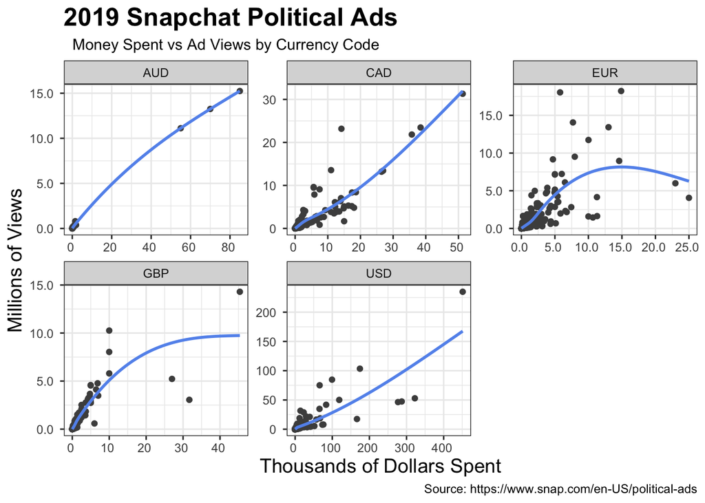

```r
ggplot(data=snapchat,mapping=aes(x=Spend,y=Impressions))+
  geom_point(color="gray30")+
  geom_smooth(se=FALSE,color="cornflowerblue")+
  facet_wrap(vars(Currency.Code),scales="free")+
  scale_y_continuous(name="Millions of Views",
                     labels=unit_format(unit="",scale=1/1000000))+
  scale_x_continuous(name="Thousands of Dollars Spent",
                     labels=unit_format(unit="",scale=1/1000))+
  labs(title="2019 Snapchat Political Ads",
       subtitle="  Money Spent vs Ad Views by Currency Code",
       caption="Source: https://www.snap.com/en-US/political-ads")+
  theme_bw()+
  theme(
        axis.title.x=element_text(size=14),
        axis.title.y=element_text(size=14),
        plot.title=element_text(face="bold",size=18))
```

# Summary

As this graphic shows, typically, the more money spent on an ad results in a higher amount of views. The direction of both the points and the regression line shows this positive relationship. According to this graphic, for the AUD, CAD, and USD currency codes, spending more money will result in more ad views and this relationship does not appear to level out. For the EUR and GBP currency codes, spending more will result in more views up until a certain point (about 10 thousand EUR and 25 thousand GBP) until the views start to level out. This shows that it is worth spending extra money, but only up to a certain point. Although it is not a main focus of the graphic, it is also interesting to see how much more money the US, and areas that use USD, spend on political advertising compared to the other currency codes.

To display the data, I chose to use a scatterplot with money spent on the x-axis and amount of views on the y-axis. Since there was an overwhelming amount of data points, I also chose to use a regression line for easier interpretation. I felt this combination was the best way to show the relationship I was aiming to display. Because each currency code had drastically different data, I allowed all the scales to be free so the regression lines and plots would fit nicely in each section. Since the 5 individual sections can initially be a lot for the viewer to take in, I decided to keep a very simple theme and avoid unnecessary colors, labels, and annotations. This allows the viewer to focus on the data itself and not get distracted by extra information.